# Thakkar_Rohan Manoj-PS3-Copy1

## Introduction to the goal of the analysis

For this analysis, I will be using the [Boston Housing Prices Data Set](http://archive.ics.uci.edu/ml/datasets/Housing).

```python
import IPython
import numpy as np
import scipy as sp
import pandas as pd
import matplotlib
import sklearn
```

```python
from sklearn.datasets import load_boston
# Loading the required data set
bdata = load_boston()
```

The following commands will provide some basic information about the shape of the data:

```python
print bdata.keys()
print bdata.feature_names
print bdata.data.shape
print bdata.target.shape
# uncomment the following if you want to see a lengthy description of the dataset
# print bdata.DESCR
```

```
['data', 'feature_names', 'DESCR', 'target']
['CRIM' 'ZN' 'INDUS' 'CHAS' 'NOX' 'RM' 'AGE' 'DIS' 'RAD' 'TAX' 'PTRATIO'
 'B' 'LSTAT']
(506L, 13L)
(506L,)
```

## Part 1: Descriptive analysis

### 1.1: Histogram of housing prices

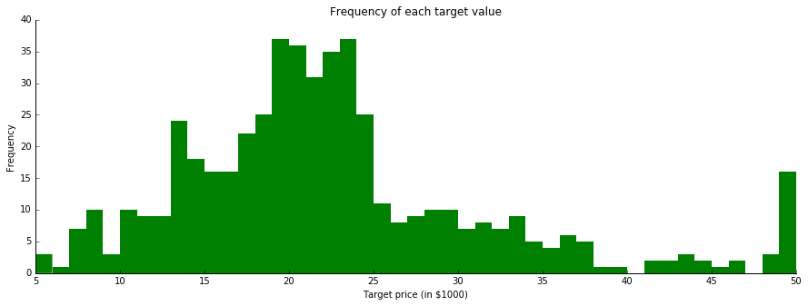

```python
# Prepare IPython to work with matplotlib and import the library to something convenient
%matplotlib inline
import matplotlib.pyplot as plt

# Spreading the plot to wider extent
plt.figure(figsize=(15,5))

# Creating a subplot of matplotlib to incorporate required modifications
ax = plt.subplot(111)

# Plotting a histogram onto the plot for the target values in a way that the bins are segregated in 1s instead of 5s so as to set
# the bin width to be $1000 instead of $5000 and setting the color of the histogram to green and remove black borders between bars
ax.hist(bdata.target, bins=np.arange(min(bdata.target), max(bdata.target) + 1, 1), color='green', edgecolor = "none")

# Hiding the right and top axes
ax.spines['right'].set_visible(False)
ax.spines['top'].set_visible(False)

# Only show ticks on the left and bottom spines
ax.yaxis.set_ticks_position('left')
ax.xaxis.set_ticks_position('bottom')


# Renaming the title and the axes of the plot
plt.xlabel("Target price (in $1000)")
plt.ylabel("Frequency")
plt.title("Frequency of each target value")
```

### 1.2: Scatter plot of housing prices and crime

Using matplotlib to create a scatter plot that shows the relationship between the median value of the home (y-axis) and the per-capita crime rate (x-axis).

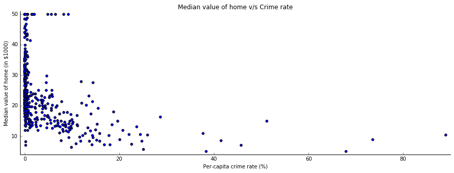

```python
# Creating a final 2-dimensional array consisiting of total 14 columns - 13 indicator variables and target values
data = np.insert(bdata.data, bdata.data.shape[1], bdata.target, axis = 1)

# Spreading the plot to wider extent
plt.figure(figsize=(15,5))

# Plotting a scatterplot with median value of home being Y-axis and per-capita crime rate being X-axis
plt.scatter(data[:,0],data[:,13])

# Creating a subplot of matplotlib to incorporate required modifications
ax = plt.subplot(111)

# Hiding the right and top axes
ax.spines['right'].set_visible(False)
ax.spines['top'].set_visible(False)

# Only show ticks on the left and bottom spines
ax.yaxis.set_ticks_position('left')
ax.xaxis.set_ticks_position('bottom')

# Renaming the X and Y axes and the title of the plot
plt.xlabel("Per-capita crime rate (%)")
plt.ylabel("Median value of home (in $1000)")
plt.title("Median value of home v/s Crime rate")

# Limiting the range of values of X and Y axes to the minimum
plt.xlim([data[:,0].min()-1,data[:,0].max()+1])
plt.ylim([data[:,13].min()-1,data[:,13].max()+1])

# Display the scatterplot
plt.show()
```

### 1.3 Create your own (creative and effective) visualization

Using another type of graph or chart to illustrate an interesting pattern in the data.

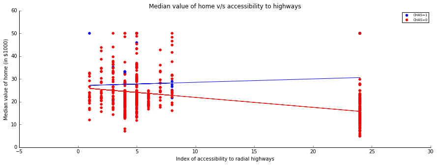

```
Thus, the regression in the case of CHAS =1 can be represented as y =  0.148845308371 * RAD + 27.0536122706  with a standard error of 0.248016557286

Similarly, the regression in the case of CHAS = 0 can be represented as y =  -0.437165350343 * RAD + 26.2761508888  with a standard error of 0.0420155974562
```

```python
# Importing package needed for fitting linear regression
import scipy.stats as stats

# Spreading the plot to wider extent
plt.figure(figsize=(15,5))

# Extracting the parameters of fitted linear regression
slope_2, intercept_2, r_value_2, p_value_2, std_err_2 = stats.linregress(data[:,8][data[:,3]==1],data[:,13][data[:,3]==1])

# Creating a subplot of matplotlib to incorporate required modifications
ax = plt.subplot(111)

# Hiding the right and top axes
ax.spines['right'].set_visible(False)
ax.spines['top'].set_visible(False)

# Only show ticks on the left and bottom spines
ax.yaxis.set_ticks_position('left')
ax.xaxis.set_ticks_position('bottom')

# First scatterplot for CHAS=1
plot1 = plt.scatter(data[:,8][data[:,3]==1],data[:,13][data[:,3]==1], color='blue')

# Writing the equation of the regression line
y_2 = slope_2*data[:,8][data[:,3]==1]+intercept_2
# Adding the above line to earlier scatter plot
plt.plot(data[:,8][data[:,3]==1], y_2, 'b-')

# Extracting the parameters of fitted linear regression
slope_3, intercept_3, r_value_3, p_value_3, std_err_3 = stats.linregress(data[:,8][data[:,3]==0],data[:,13][data[:,3]==0])

# Second scatterplot for CHAS=0
plot2 = plt.scatter(data[:,8][data[:,3]==0],data[:,13][data[:,3]==0], color='red')

# Writing the equation of the regression line
y_3 = slope_3*data[:,8][data[:,3]==0]+intercept_3
# Adding the above line to earlier scatter plot
plt.plot(data[:,8][data[:,3]==0], y_3, 'r-')

# Adding legend to graph
plt.legend((plot1,plot2),
           ('CHAS=1','CHAS=0'),
           scatterpoints=1,
            loc='upper right',
           fontsize=7)

# Naming the title, x-axis and y-axis of the plot
plt.title("Median value of home v/s accessibility to highways")
plt.xlabel("Index of accessibility to radial highways")
plt.ylabel("Median value of home (in $1000)")
plt.show()

# Plotting a line y = slope*x where slope is determined from the above regression and x is the predictor variable, i.e., 'hour'
print 'Thus, the regression in the case of CHAS =1 can be represented as y = ',slope_2,'* RAD', '+', intercept_2,' with a standard error of',std_err_2

# Plotting a line y = slope*x where slope is determined from the above regression and x is the predictor variable, i.e., 'hour'
print '\nSimilarly, the regression in the case of CHAS = 0 can be represented as y = ',slope_3,'* RAD', '+', intercept_3,' with a standard error of',std_err_3
```

Thus, we understand that the correlation between median value of home and the index of accessibility to radial highways is postive if Charles tract bound river (CHAS=1) whereas the same correlation holds a negative value otherwise(CHAS=0.)

This shows us the importance of using a filter variable while analyzing the relationship between two other variables. The correlation may depend on the filter variables as well, like CHAS in the above case.

## Part 2: Experimental Setup

The goal of the next few sections is to design an experiment to predict the median home value for an instance in the data.

### 2.1 Writing a function to compute the Root Mean Squared Error for a list of numbers

```python
# Defining the function which takes two arrays as inputs - predictions and yvalues
def compute_rmse(predictions, yvalues):
    # Calculating the resultant array of squared-difference between parallel entries of two arrays
    dif = (predictions-yvalues)**2
    # Defining RMSE equal to (sum of squares of difference)/(length of either array)
    rmse = np.sqrt(dif.sum()/float(len(predictions)))
    # Functions returns rmse as output
    return rmse
```

### 2.2 Dividing data into training and testing datasets

Randomly selecting 66% of the data and put this in a training dataset (call this "bdata_train"), and placing the remaining 34% in a testing dataset (call this "bdata_test")

```python
# leave the following line untouched, it will help ensure that your "random" split is the same "random" split used by the rest of the class
np.random.seed(seed=13579)

# Defining a splitting function that takes as input the given array and percentage of split
def split(data, per_train):
    # Shuffled the input data randomly, based on the seed above
    np.random.shuffle(data)
    # Inserts the top train% rows (66 in this case) to the 'train' array
    train = data[0:per_train*len(data),:]
    # Inserts the bottom (1--0train)5 rows to the 'test' array
    test = data[per_train*len(data):len(data),:]
    # Return the resultant arrays
    return train, test

# Splitting the overall data to 66% in training and 34% in test and storing the resultants in bdata_train and bdata_test
bdata_train, bdata_test = split(data, 0.66)
```

### 2.3 Use a very bad baseline for prediction, and compute RMSE

- Creating a model that predicts, for every observation x_i, that the median home value is the average (mean) of the median values for all instances in the training set.
- Computing the RMSE on the training set.
- Compute the RMSE on the test data set. How does RMSE compare for training vs. testing datasets? Is this expected, and why?

```python
# Applying the RSME function on 'target' column of train array and its mean value
print "RMSE of training set is",compute_rmse(bdata_train[:,13],[bdata_train[:,13].mean()])

# Applying the RSME function on 'target' column of test array and the mean value of train's 'target' column
print "RMSE of test set is",compute_rmse(bdata_test[:,13],[bdata_train[:,13].mean()])
```

```
RMSE of training set is 8.58496788378
RMSE of test set is 10.2816716248
```

I expected the RMSE to be higher for the test case as compared to the training because the basis of comparison was with the mean of median values of all tuples in the training set and it will be relatively closer to the range of values held by training as compared to the range of values held in the test set. The above calculated values prove this assumption to be correct.

## Part 3: Nearest Neighbors

### 3.1 Nearest Neighbors: Distance function

Building a machine learning algorithm to beat the "Average Value" baseline computed above. Writing a generic function to compute the L-Norm distance (called the *p*-norm distance on Wikipedia).

```python
# Defining a new function 'distance' that takes as input two arrays and the value of L to calculate L-norm distance
def distance(x1, x2, L):
    # Returns the Lth power of absolute difference between x1 and x2
    dist = np.power(np.abs(x1-x2),L)
    # returns the array consisting of Lth root values of distance between every parallel combination of items from x1 and x2
    return np.power(dist.sum(axis=1),float(1)/L)
```

### 3.2 Basic Nearest Neighbor algorithm

Now things get fun. Now, I will implement a basic nearest neighbor algorithm from scratch. The simple model will use two input features (CRIM and RM) and a single output (MEDV). In other words, I am modelling the relationship between median home value and crime rates and house size.

Using the training data (bdata_train) to "fit" the model, although as I know, with Nearest Neighbors there is no real training, you just need to keep your training data in memory.

Here, I will write a function that predicts, for each instance in the testing data (bdata_test), the median home value using the nearest neighbor algorithm we discussed in class. Since this is a small dataset, I can simply compare your test instance to every instance in the training set, and return the MEDV value of the closest training instance. Have the function take L as an input, where L is passed to the distance function.

Compute the RMSE for the Nearest Neighbor predictions on the test set, using the Euclidean distance. Report an estimate of the total time taken by your code to predict the nearest neighbors for all the values in the test data set.

```python
# To calculate total time required
import time

# To sort an array
import operator

# test = x, train = y, train's target = z, test's target = u, L = value of L for L-norm distance
def nneighbor(x, y, z, u, L):
    # Storing the start-time for reference
    start_time = time.time()
    # Defining a new list to store miinmum distance for each element in test array
    a = []
    # For each 'item' in test array
    for i in x:
        # Calculates the distance for an instance in test from each instance in train and store the resultant as an array
        dis = distance(i,y,L)
        # Combine distance array and train's 'target' column as one array
        yolo = np.column_stack((dis,z))
        # Sort the above 2-dimensional array in an ascending order of distance to get the entry with minimum distance
        yolo = sorted(yolo, key=operator.itemgetter(0), reverse=False)
        # Append the minimum distance to the final list
        a.append(yolo[0])
    # Convert list to array
    a = np.array(a)
    # Calculate the time taken by algorithm so far (to predict the nearest neighbors for all values in test array)
    t1 = float(round(time.time() - start_time,2))
    # Returns the above value of time and RMSE of 'target' values of test as compared to distance of each test case from its
    # nearest neighbor
    return t1,compute_rmse(u,a[:,1])

# t = total time taken, n = RMSE
t,n = nneighbor(bdata_test[:,(0,5)], bdata_train[:,(0,5)],bdata_train[:,13],bdata_test[:,13],2)
print "RMSE is",n
print "Time taken is",t,"seconds"
```

```
RMSE is 7.45009989459
Time taken is 0.17 seconds
```

### 3.3 Results and Normalization

However, I have not normalized our features above -- a big no-no with Nearest Neighbor algorithms. Writing a generic normalization function that takes as input an array of values for a given feature, and returns the normalized array (subtract the mean and divide by the standard deviation).

Re-running the Nearest Neighbor algorithm on the normalized dataset (still just using CRIM and RM as input), and comparing the RMSE from this method with your previous RMSE evaluations.

```python
def normalize(raw_data):
    # creates a new 1-D column array of zeros of length equal to number of rows in input data
    normalized_data = np.zeros((raw_data.shape[0]))
    # iterates through each column in input data
    for j in range(raw_data.shape[1]):
        # calculates the mean value of entries in jth column of input data
        mean = raw_data[:,j].mean()
        # calculates the standard deviation of entries in jth column of input data
        std = raw_data[:,j].std()
        # stores the noramlized value of all entries in jth column into another array
        a = (raw_data[:,j]-mean)/std
        # appends this array to original array which is to be returned
        normalized_data=np.column_stack((normalized_data,a))
    # converts the effective list of combined columns (noramlized data) into a 2-dimensional array
    nor = np.array(normalized_data)
    # returns the entire array except for the first column which consists of only zeroes
    return nor[:,(xrange(1,raw_data.shape[1]+1))]


# Running the nneighbor algorithm on normalized CRIM and RM columns as input and un-normalized target values with L=2
t1, n1 = nneighbor(normalize(bdata_test[:,(0,5)]), normalize(bdata_train[:,(0,5)]),bdata_train[:,13],bdata_test[:,13],2)
print "RMSE is",n1
print "Time taken is",t1,"seconds"
```

```
RMSE is 7.73437264626
Time taken is 0.11 seconds
```

### 3.4 Optimization

What combination of features and distance function provide the lowest RMSE? Do your decisions affect the running time of the algorithm?

```python
# Running the nneighbor algorithm on normalized CRIM and RM columns as input and un-normalized target values with L=3
t2, n2 = nneighbor(normalize(bdata_test[:,(0,5)]), normalize(bdata_train[:,(0,5)]),bdata_train[:,13],bdata_test[:,13],3)

print "Time taken:",t2," seconds"
print "RMSE is",n2

# Running the nneighbor algorithm on normalized CRIM and RM columns as input and un-normalized target values with L=4
t3, n3 = nneighbor(normalize(bdata_test[:,(10,12)]), normalize(bdata_train[:,(10,12)]),bdata_train[:,13],bdata_test[:,13],4)

print "Time taken:",t3," seconds"
print "RMSE is",n3

# Running the nneighbor algorithm on normalized CRIM,RM,PTRATIO and LSTAT columns as input and un-normalized target values with L=2
t4, n4 = nneighbor(normalize(bdata_test[:,(0,5,10,12)]), normalize(bdata_train[:,(0,5,10,12)]),bdata_train[:,13],bdata_test[:,13],2)

print "Time taken:",t4," seconds"
print "RMSE is",n4

# Running the nneighbor algorithm on normalized CRIM,RM,PTRATIO and LSTAT columns as input and un-normalized target values with L=4
t5, n5 = nneighbor(normalize(bdata_test[:,(0,5,10,12)]), normalize(bdata_train[:,(0,5,10,12)]),bdata_train[:,13],bdata_test[:,13],4)

print "Time taken:",t5," seconds"
print "RMSE is",n5
```

```
Time taken: 0.1  seconds
RMSE is 7.75256437157
Time taken: 0.13  seconds
RMSE is 6.55767211622
Time taken: 0.14  seconds
RMSE is 5.99873782485
Time taken: 0.14  seconds
RMSE is 6.05098281799
```

On trying the some different combinations of features and L, we observe that the RMSE does, indeed, change a lot based on the features we choose but not a lot on the value of L. We can assume that since the RMSEs for L=2 and L=3 are comparable while CRIM and RM features are considered(7.73 and 7.75). Similarly, the RMSE for L=2 and L=4 are comparable while CRIM,RM,PTRATIO and LSTAT features are considered (5.99 and 6.05).

However, we maybe able to assume that on a general note, as more features are added, the RMSE decreased as web observe from above that RMSE for the case wherein CRIM,RM,PTRATIO and LSTAT features are considered as compared to the case wherein only CRIM and RM features are considered. However, this assumption holds true as long as the number of features do not exceed the threeshold of overfitting the data in any given case.

On a general note, we can assume that the running time of the algorithm is higher for a higher value of k (for equal number of features) because of additional computation time required to incoporate these extra loops. Similarly, the running time is higher for a higher number of features (for a constant value of k). However, in the above example, since there is only a minor difference in the values of k considered and the number of features observed, there is not much difference in running time of algorithm in the different cases.

### 3.5 Cross-Validation

The more I tinker with your features and distance function, the higher the risk that you overfit your training data. To prevent this sort of overfitting, I need to use cross-validation. Here I will implement a simple k-fold cross-validation algorithm yourself.

Using a 10-fold cross-validation and report the average RMSE for Nearest Neighbors using Euclidean distance with CRIM and RM input features, as well as the total running time for the full run of 10 folds. In other words, I will randomly divide the dataset into 10 equally-sized samples, and for each of 10 iterations (the "folds"), I will use 9 samples as "training data" (even though there is no training in k-NN!), and the remaining 1 sample for testing.

Then, I will compute the RMSE of that particular test set, then move on to the next iteration. Once done, I will report the average RMSE across the 10 iterations.

```python
def k_fold(df,v,L,s,k,k_fold):
    # Setting the overall timer and sum of RMSEs to 0
    t_o = 0.0
    n_o = 0.0
    # for the number of folds
    for i in range(k_fold):
        # test array will consists of a different 10% subset of the overall arrau
        test = df[xrange(int(float(i)/10*df.shape[0]),int((float(i+1)/10)*df.shape[0])),:]
        # train = overall data - test data
        train = np.delete(df,(xrange(int(float(i)/10*df.shape[0]),int((float(i+1)/10)*df.shape[0]))), axis=0)
        # target values for test data
        v_test = v[xrange(int(float(i)/10*df.shape[0]),int((float(i+1)/10)*df.shape[0]))]
        # target values for train data
        v_train = np.delete(v,(xrange(int(float(i)/10*df.shape[0]),int((float(i+1)/10)*df.shape[0]))))
        # if implementing knn algorithm (defined later in the problem set)
        if s=='knn':
            t_n, n_n = knn(normalize(test), normalize(train),v_train,v_test,L,k)
        # if implementing nneighbor algorithm
        elif s=='nneighbor':
            t_n, n_n = nneighbor(normalize(test), normalize(train),v_train,v_test,L)
        # adding time taken for this iteration to total time
        t_o+=t_n
        # adding RMSE for this iteration to total RMSE value
        n_o+=n_n
    # Returns average RMSE across number of folds and total time taken
    return (n_o/k_fold), t_o

# Total time taken and RMSE for 10-fold cross validation on CRIM and RM input features
p,q = k_fold(data[:,(0,5)],data[:,13],2,'nneighbor',3,10)
print "Average RMSE is:",p
print "Total Time taken:",q," seconds"
```

```
Average RMSE is: 6.42725205407
Total Time taken: 0.52  seconds
```

### 3.6 K-Nearest Neighbors Algorithm

Implementing the K-Nearest Neighbors algorithm. Using 10-fold cross validation, reporting the RMSE for K=3 and the running time of the algorithm.

```python
# test = x train = y
def knn(x, y, z, u, L, k):
    # storing start time
    start_time = time.time()
    # empty array to store distance and target values
    a = []
    # for each entry in test
    for i in x:
        # array of L-norm distance of that test entry from the entire train column
        dis = distance(i,y,L)
        # appending distance and target values to a single 2-D array
        yolo = np.column_stack((dis,z))
        # sorting the above array in an ascending order of distance
        yolo = sorted(yolo, key=operator.itemgetter(0), reverse=False)
        # Appending the mean distance across the k nearest neighbors to list a
        a.append(np.mean(yolo[0:k], axis = 0))
    # converting to array
    a = np.array(a)
    # Total time taken by algorithm
    t1 = float(round(time.time() - start_time,2))
    # returning time taken and RMSE of tagret values of train v/s test
    return t1,compute_rmse(u,a[:,1])


# runs a 10-fold cross validation for knn where k=3 for CRIM and RM columns
r,s = k_fold(data[:,(0,5)],data[:,13],2,'knn',3,10)
print "Average RMSE is:",r
print "Total Time taken:",s," seconds"
```

```
Average RMSE is: 5.88061503344
Total Time taken: 0.78  seconds
```

### 3.7 Using cross validation to find K

I will create a graph that shows how RMSE changes as K increases from 1 to 25.

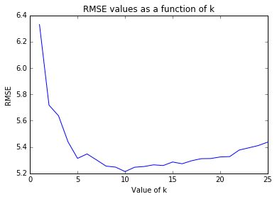

```
Thus, we can see that the RMSE attains its minimum value of 5.2135835165 for k = 10
```

```python
# creating a new array with noramlized CRIM, ZN, RM, AGE, DIS and TAX columns as well as target values from original data
data_new = np.column_stack((normalize(data[:,(0,1,5,6,7,9)]),data[:,13]))

# Thus, order of columns in new data: (0-5)==(CRIM, ZN, RM, AGE, DIS, TAX); 6==target

# Empty lists
x=[]
y=[]

# for k=1 to k=25
for ele in xrange(1,26):
    # Calculating the RMSE and time taken
    n,t = k_fold(data_new[:,0:5],data_new[:,6],2,'knn',ele,10)
    # Appending the value of iteration to x list
    x.append(ele)
    # Appending corresponding RMSE value to y list
    y.append(n)

# Creating a 2-D array with first column being x and second being y
k_table = np.array(np.column_stack((x,y)))

# Plotting the RMSE values as a function of k
plt.plot(k_table[:,0],k_table[:,1])

# Renaming the title and the axes of the plot
plt.xlabel("Value of k")
plt.ylabel("RMSE")
plt.title("RMSE values as a function of k")

# display the plot
plt.show()

# Sorting the 2-D array according to increasing value of RMSE values
k_table = np.array(sorted(k_table, key=operator.itemgetter(1), reverse=False))

# Thus, the minimum possible value of RMSE will be the value at 1st row (row==0) and 1st column (col==0) of the sorted 2-D array
print "Thus, we can see that the RMSE attains its minimum value of",k_table[0][1],"for k =",int(k_table[0][0])
```

Here, we see that the function of RMSE v/s k is like a upper-facing curve with its local minima being at k=10, which means that the lowest value of RMSE is observed at k=10, i.e., for 10-nearest neighbors for k in the range of 1-25. As a result, we may assume the 10 is a reasonable choice of k for this model as it minimizes the resultant RMSE value.